# VLN Analysis for prediction of Pathogenic / Benign

David McGaughey

September 7, 2016

## R Markdown

Analysis of the performance of VLN (variant lanscape numbers, 100bp window, GRCh38) in categorizing ClinVar pathogenic against benign variants. CADD used as the ‘gold standard’ to compare performance.

[output not shown]

Exploratory analysity with summary stats and density plots of VLN in benign and pathogenic variant sets.

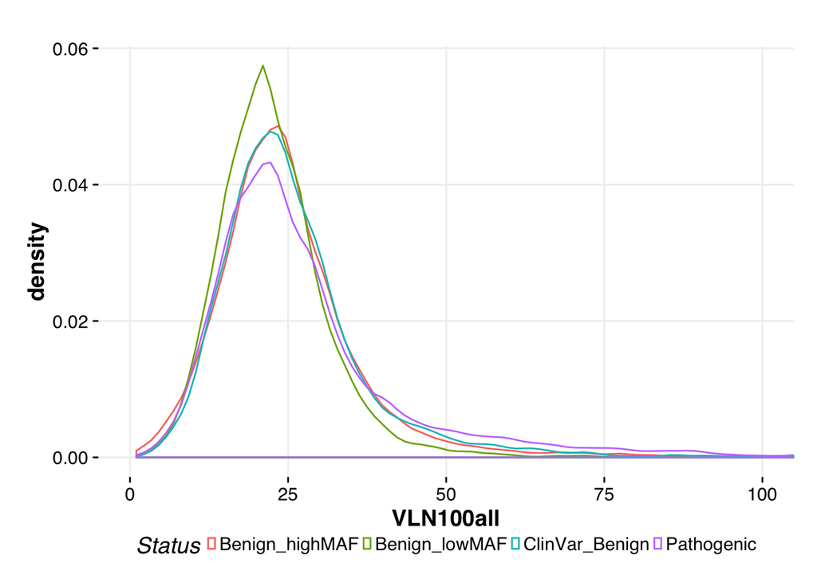

```r
##########
# exploratory analysis, quick stats

# gather/melt
training_set.m <- training_set %>% gather(.,VLN,Value,-Chr,-Position,-ID,-Ref,-Alt,-Variant_Class,-GMAF,-ExAC,-CADD_phred, -CADD_raw, -CADD_raw_rankscore, -PolyPhen, -SIFT, -Clin_Sig, -GMAF0, -ExAC0, -Status)
# density plot
training_set %>% ggplot(aes(x=VLN100all, colour=Status))+geom_density() + theme_Publication() + coord_cartesian(xlim=c(0,100))
```

Uh….everything looks about the same. This isn’t how the earlier plot looked. Let’s look at some numbers.

```r
# summary stats by VLNtype and Pathogenic/Benign
training_set.m %>% group_by(VLN,Status) %>% summarise(mean(Value), median(Value),`25th_percentile`=quantile(Value,0.25),`75th_percentile`=quantile(Value,0.75),Total=n())
```

```
## Source: local data frame [16 x 7]
## Groups: VLN [?]
##
##               VLN         Status mean(Value) median(Value) 25th_percentile
##             <chr>          <chr>       <dbl>         <dbl>           <dbl>
## 1       VLN100all Benign_highMAF   25.317509            23              18
## 2       VLN100all  Benign_lowMAF   23.265781            22              17
## 3       VLN100all ClinVar_Benign   26.757835            24              18
## 4       VLN100all     Pathogenic   29.879739            24              18
## 5      VLN100high Benign_highMAF    1.613214             1               0
## 6      VLN100high  Benign_lowMAF    1.381511             1               0
## 7      VLN100high ClinVar_Benign    2.650709             1               0
## 8      VLN100high     Pathogenic    4.930123             2               1
## 9       VLN100low Benign_highMAF    7.566020             7               5
## 10      VLN100low  Benign_lowMAF    6.979427             7               5
## 11      VLN100low ClinVar_Benign    7.420893             7               5
## 12      VLN100low     Pathogenic    6.872908             6               4
## 13 VLN100moderate Benign_highMAF   16.136018            15              11
## 14 VLN100moderate  Benign_lowMAF   14.903230            14              10
## 15 VLN100moderate ClinVar_Benign   16.684277            15              11
## 16 VLN100moderate     Pathogenic   18.076956            15              11
## # ... with 2 more variables: 75th_percentile <dbl>, Total <int>
```

So….pathogenic seems to generally have a higher VLN than the ‘benign’. Which is opposite my initial finding. And our expectation. What is going on here? The answer is very simple, but it took me a while to figure out. Let’s pull in ensembl’s clinvar_only variant set, and remake the plot (this is what was used for the Molecular Rounds fig in August) and see the summary stats.

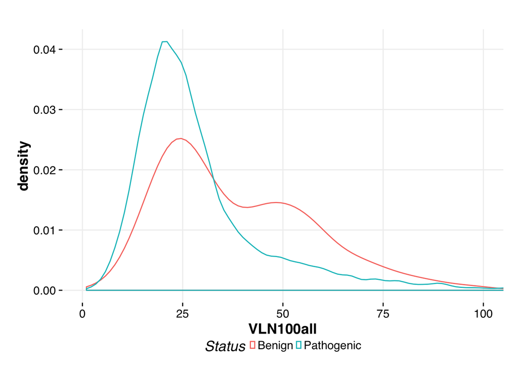

```r
# recreate the density plot we've seen before:
clinOnly_vcf %>% filter(Status!='Conflicting', Status!='Other') %>%
  ggplot(aes(x=VLN100all, colour=Status))+geom_density() + theme_Publication() + coord_cartesian(xlim=c(0,100))
```

```r
# summary stats, as above:
clinOnly_vcf %>% gather(.,VLN,Value,-V1,-V2,-V3,-V4,-V5,-V6,-V7,-V8,-ClinSig,-Status) %>% group_by(VLN, Status) %>% filter(Status!='Conflicting', Status!='Other') %>% summarise(mean(Value), median(Value),`25th_percentile`=quantile(Value,0.25),`75th_percentile`=quantile(Value,0.75),Total=n())
```

```
## Source: local data frame [8 x 7]
## Groups: VLN [?]
##
##              VLN     Status mean(Value) median(Value) 25th_percentile
##            <chr>      <chr>       <dbl>         <dbl>           <dbl>
## 1      VLN100all     Benign   40.295324       34.0000         23.0000
## 2      VLN100all Pathogenic   31.556267       25.0000         18.6667
## 3     VLN100high     Benign    9.827906        4.0000          1.0000
## 4     VLN100high Pathogenic    5.362295        2.0000          1.0000
## 5      VLN100low     Benign    7.679024        7.0000          5.0000
## 6      VLN100low Pathogenic    7.011957        6.0000          4.0000
## 7 VLN100moderate     Benign   22.783425       21.0000         15.0000
## 8 VLN100moderate Pathogenic   19.182271       15.7143         11.0000
## # ... with 2 more variables: 75th_percentile <dbl>, Total <int>
```

OK, the plot looks the same. BUT: What immediately pops out is how FEW benign variants there are. Did I screw up the filtering?

```r
# checking number of benign (of ANY kind) in original vcf
orig_clin %>% filter(grepl('benign',V8)) %>% nrow()
```

```
## [1] 1238
```

1238….so for some reason there are VERY VERY few benigns.

I then downloaded the latest clinvar vcf from NCBI’s ftp site: ftp://ftp.ncbi.nlm.nih.gov/pub/clinvar/ clinvar_20160831.vcf.gz

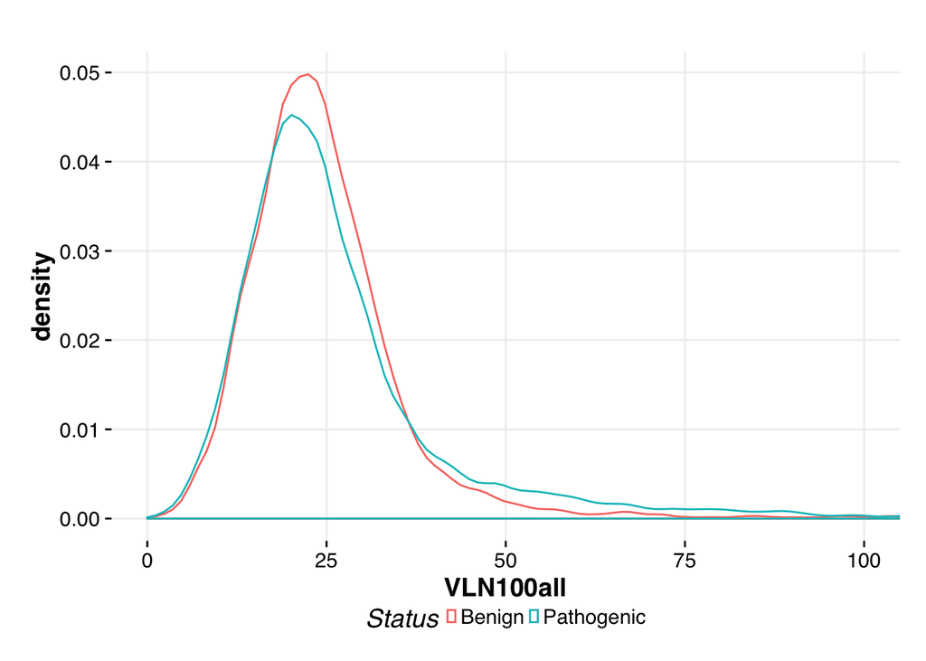

```r
# let's make a new density plot
clinOnly_vcf_latest %>% filter(ClinSig %in% c(2,5)) %>% mutate(Status=ifelse(ClinSig==2,'Benign','Pathogenic')) %>%
  ggplot(aes(x=VLN100all, colour=Status))+geom_density() + theme_Publication() + coord_cartesian(xlim=c(0,100))
```

```r
# summary stats
clinOnly_vcf_latest %>% filter(ClinSig %in% c(2,5)) %>% mutate(Status=ifelse(ClinSig==2,'Benign','Pathogenic')) %>%
  gather(.,VLN,Value,-V1,-V2,-V3,-V4,-V5,-V6,-V7,-V8,-ClinSig,-Status) %>%
  group_by(VLN, Status) %>% summarise(mean(Value), median(Value),quantile(Value,0.25),quantile(Value,0.75),Total=n())
```

```
## Source: local data frame [8 x 7]
## Groups: VLN [?]
##
##              VLN     Status mean(Value) median(Value)
##            <chr>      <chr>       <dbl>         <dbl>
## 1      VLN100all     Benign   24.864546            23
## 2      VLN100all Pathogenic   28.272960            23
## 3     VLN100high     Benign    1.821437             1
## 4     VLN100high Pathogenic    4.528009             2
## 5      VLN100low     Benign    7.445985             7
## 6      VLN100low Pathogenic    6.752817             6
## 7 VLN100moderate     Benign   15.595743            15
## 8 VLN100moderate Pathogenic   16.993107            14
## # ... with 3 more variables: quantile(Value, 0.25) <dbl>, quantile(Value,
## #   0.75) <dbl>, Total <int>
```

Well, let’s proceed since I’ve done 95% of the hard work and see whether the VLN numbers have any ability to distinguish benign from pathogenic variants

Keep your expectations low. very low.

First let’s see how well CADD does Since CADD did a ROC test on higher MAF variants vs clinvar pathogenic in their paper, I’ll do the same

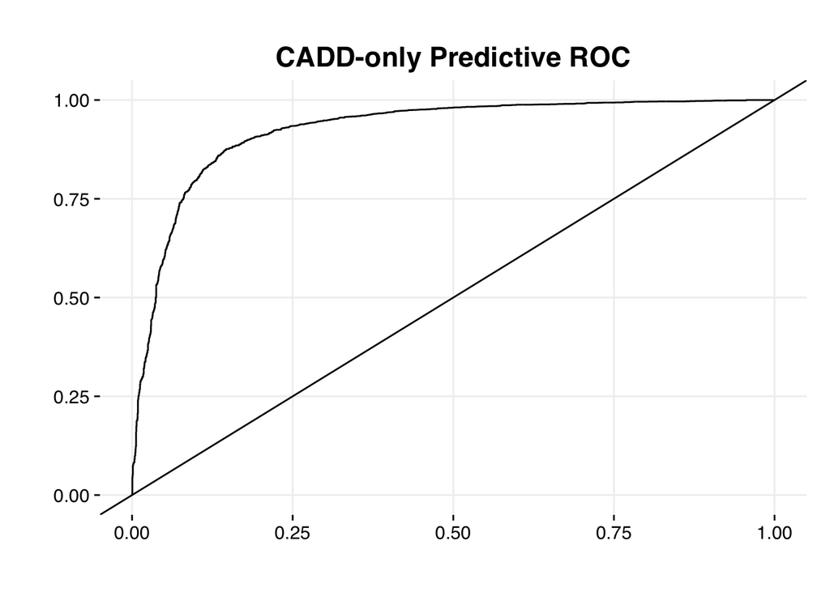

```r
# plot ROC, which shows performance against 50/50 guessing
ggplot(glm_caddOnly_roc,aes(x=X1,y=X2)) + geom_line() + theme_Publication() + xlab('') + ylab('') + geom_abline() + ggtitle("CADD-only Predictive ROC")
```

```r
# CADD's auc (1 is perfect, 0 is worthless) is 0.92. Very good
auc.tmp <- performance(pred,"auc"); as.numeric(auc.tmp@y.values)
```

```
## [1] 0.9243615
```

CADD’s auc (1 is perfect, 0.5 is a monkey flipping coins) is 0.92. Very good

Let’s see if the ROC/AUC improves by adding the VLN to the CADD

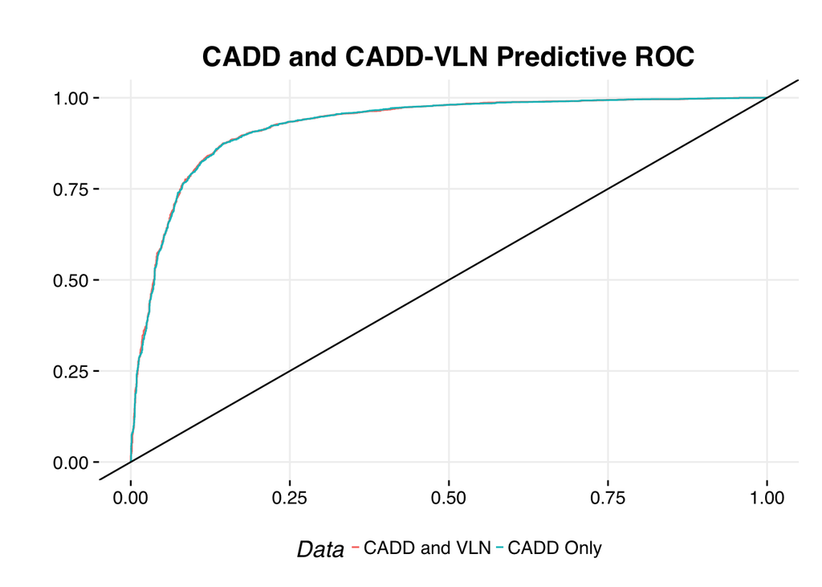

```r
# yeah....not helping much
ggplot(both,aes(x=X1,y=X2,colour=Data)) + geom_line() + theme_Publication() + xlab('') + ylab('') + geom_abline() + ggtitle("CADD and CADD-VLN Predictive ROC")
```

```r
# auc is virtually identical, after adding VLN to the predictor
auc.tmp <- performance(pred,"auc"); as.numeric(auc.tmp@y.values)
```

```
## [1] 0.9248127
```

Uh, no. Not at all.

Let’s quickly see how VLN does ALONE as a predictor

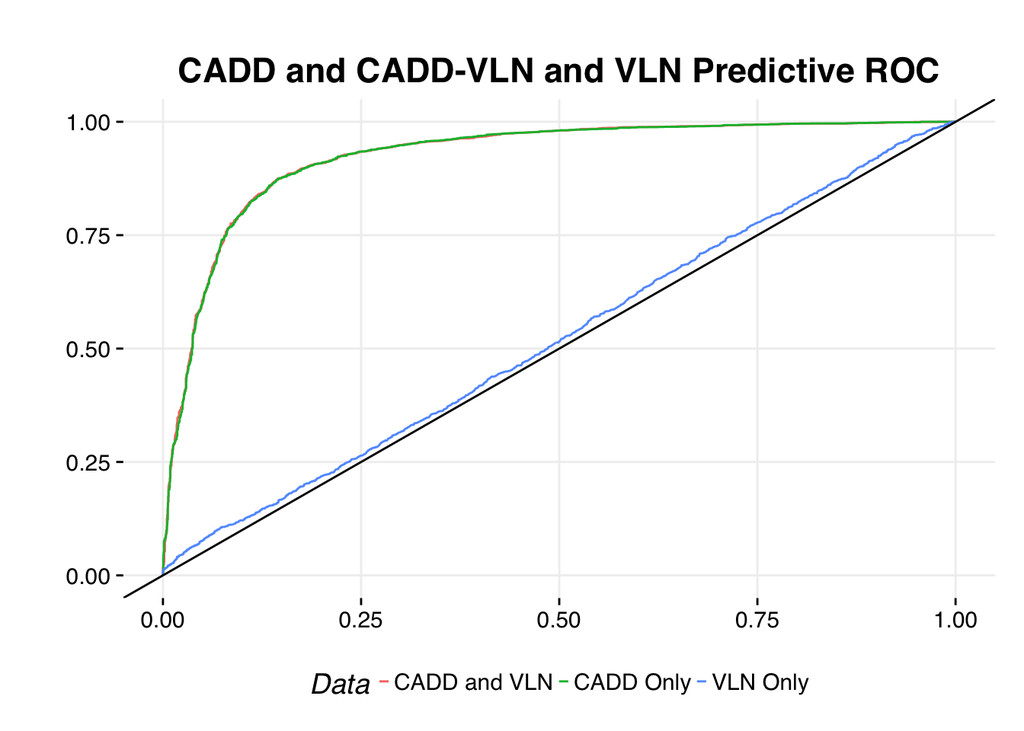

```r
# not so hot
ggplot(triple,aes(x=X1,y=X2,colour=Data)) + geom_line() + theme_Publication() + xlab('') + ylab('') + geom_abline() + ggtitle("CADD and CADD-VLN and VLN Predictive ROC")
```

```r
# also bad
auc.tmp <- performance(pred,"auc"); as.numeric(auc.tmp@y.values)
```

```
## [1] 0.5198679
```

Well crap.

[output not shown]

Also tested VLN only with a random forest, as it is less sensitive to poor optimization

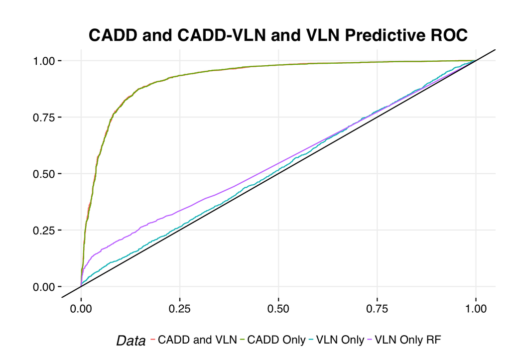

```r
# still not so hot
ggplot(quad,aes(x=X1,y=X2,colour=Data)) + geom_line() + theme_Publication() + xlab('') + ylab('') + geom_abline() + ggtitle("CADD and CADD-VLN and VLN Predictive ROC")
```

```r
# still also bad
auc.tmp <- performance(pred,"auc"); as.numeric(auc.tmp@y.values)
```

```
## [1] 0.5520154
```

Summary? This isn’t working. We could try doing VLN with CADD scores to see whether the idea of ‘regional’ or ‘landscape’ genome variation has any merit. It’s possible that straight up counts is a crappy metric.